# Task3 - Exploratory Data Analysis

```r
library(here)
sample <- read.csv2(here("data", "sample.tsv"), sep="\t", header=TRUE)
```

## Data Overview

```r
head(sample)
```

```
##    gene_id count
## 1 15S_rRNA     8
## 2 21S_rRNA    34
## 3     HRA1     0
## 4     ICR1   194
## 5     LSR1     9
## 6     NME1    10
```

```r
dim(sample)
```

```
## [1] 7126    2
```

```r
sum(sample$count==0)
```

```
## [1] 1090
```

```r
min(sample$count)
```

```
## [1] 0
```

```r
max(sample$count)
```

```
## [1] 194695
```

```r
mean(sample$count)
```

```
## [1] 749.3153
```

```r
sd(sample$count)
```

```
## [1] 3836.892
```

# Plotting

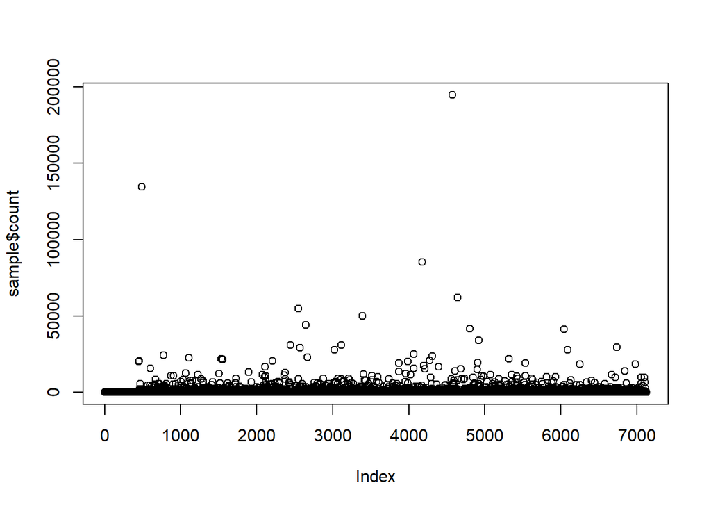

```r
plot(sample$count)
```

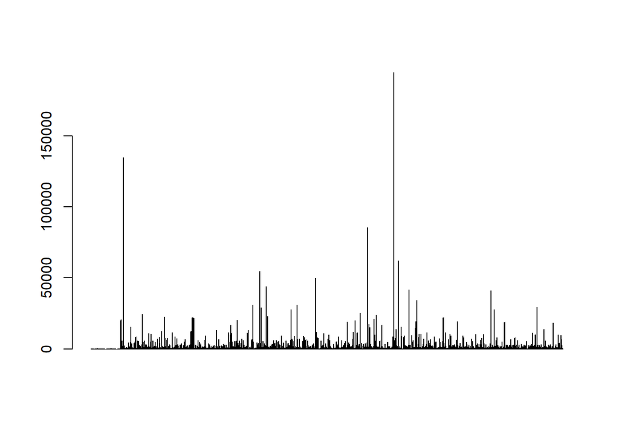

```r
barplot(sample$count)
```

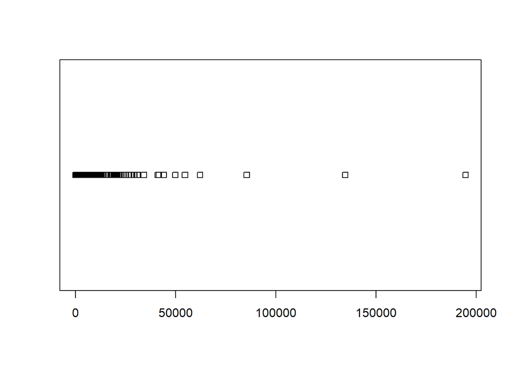

```r
stripchart(sample$count)
```

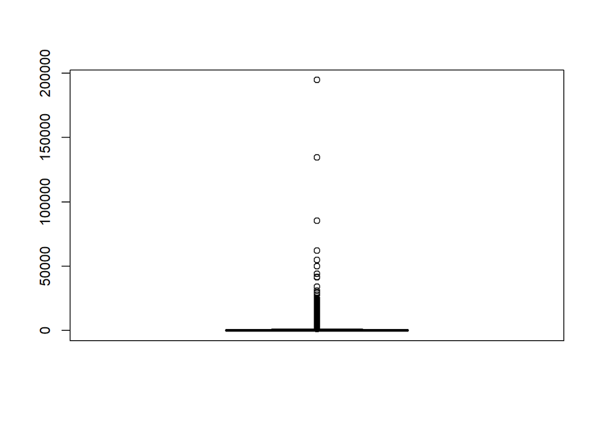

```r
boxplot(sample$count)
```

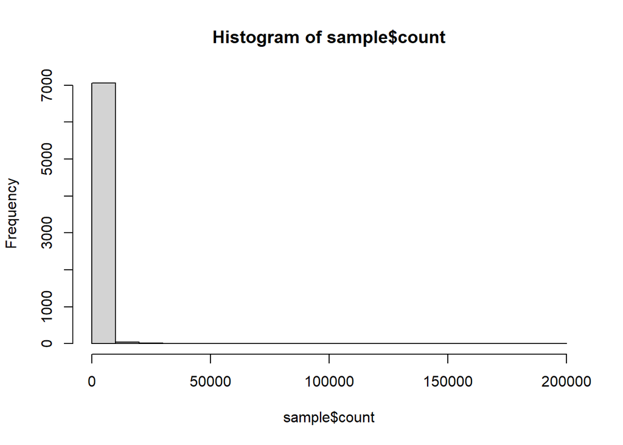

```r
hist(sample$count)
```

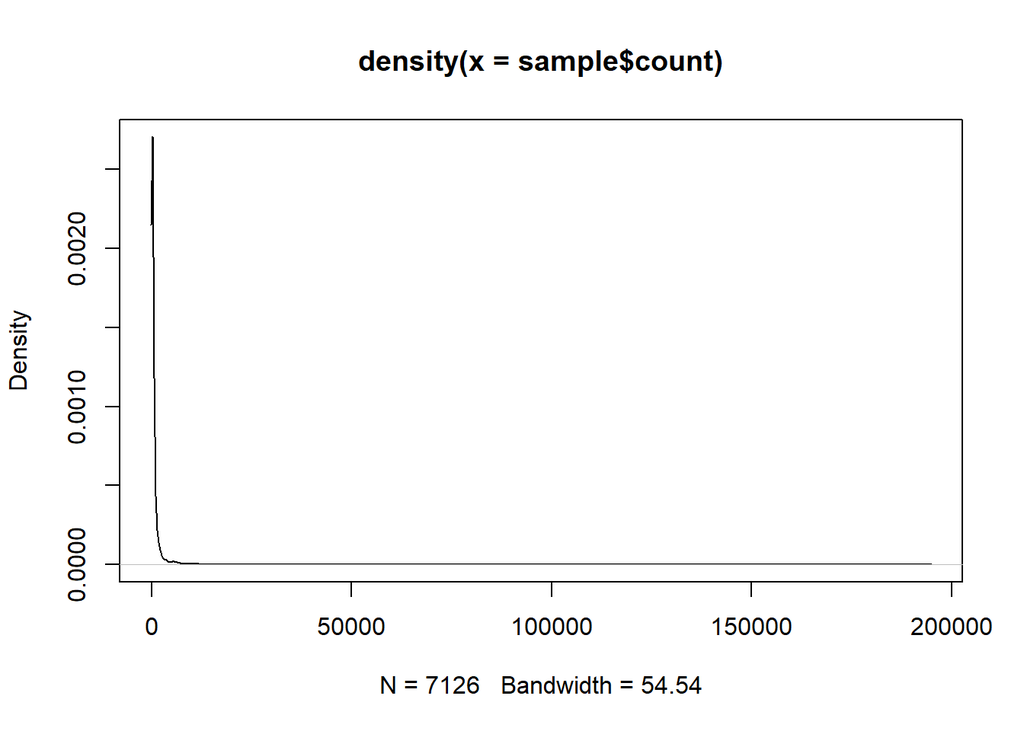

```r
plot(density(sample$count))
```

### Methodology and Code Implementation

- Row 8: `read.csv2`imports the data of the chosen file (sample.tsv); the parameters specify that the file uses tabs (sep=“) as separators and contains column names in the first row (header = TRUE)
- Row 13: `head()`shows the first six rows of the dataset to provide a quick look into the data structure
- Row 14: `dim()` shows the dimensions of the dataset (number of rows and columns)
- Row 15: `sum(sample$count==0)`calculates the total number of genes without expression
- Row 20 & 21: `min()`/ `max()` identify the lowest/ highest expression values in the column “count”
- Row 22: `mean()` calculates the average expression level
- Row 23: `sd()` calculates the standard deviation (shows dispersion around the average)
- Row 27-32: create 6 different plot as visual representation of the values

### Statistical Analysis

- Data Preview: shows the first 6 genes and its amount of expression. For example, in these 6 genes, the highest expression is in gene ICR1 with 194 counts.
- General statistics: Result of `dim()` with **7,126** rows (= genes) and 2 columns (gene_id and counts) **1,090** genes have an expression value of zero the counts range from a min of **0** counts to a max. **194,695** counts (no transciption under these circumstances) the mean is approximately **749** counts, the sd **3,837** counts(high sd indicates a high level of dispersion)

### Visual Interpretation

- Indexplot: each point represents one gene. The x-axis could be the row number in the table, the y-axis the expression count Most genes have low expression (**under 30,000** counts) while few outliers are expressed highly (**>100,000** counts)
- Barplot: shows a expression as a bar for each gene in the dataset. its shows the same like the Indexplot, just a different type of graphics/ visualization.
- Stripchart: is a one-dimensional scatter plot, that stacks the expression values on an horizontal axis. shows high density and gaps in the expression of genes of this dataset.
- Boxplot: the box (not visible) represents the middle 50% of the data. looks like a line in the bottom part, because the mean and most values have similar expression rates
- Histogram: gathers frequencies of different expression rates in columns. Each column represents 10,000 counts in expression rate. the first column contains almost all values
- Density plot: is a smoothed version of the Histogram showing the probability distribution. The steep peak in the beginning shows the high concentration of low expression values in most genes